# Effects of Diagram Standards on Students’ Monitoring Accuracy and Text Comprehension - Printed Summary of Analyses for Study 1 and 2

Sophia

2023-11-20

# Study 1 - Methods

## Participants, Design, Time On Task & Inter-Rater-Reliability of Measures

Descriptives of Age n = 80

| Mean | SD | Min | Max |
| --- | --- | --- | --- |
| 20.27 | 1.76 | 18 | 28 |

Gender Distribution n = 80

| Sex | n | % |
| --- | --- | --- |
| Female | 28 | 35 |
| Male | 52 | 65 |

Descriptives of Age n = 79

| Mean | SD | Min | Max |
| --- | --- | --- | --- |
| 20.26 | 1.79 | 18 | 28 |

Gender Distribution n = 79

| Sex | n | % |
| --- | --- | --- |
| Female | 26 | 33.77 |
| Male | 51 | 66.23 |

n (Previous Drop-Out & Final) and Time On Task per Condtition

| Experiment | Condition | n Drop_Out | n Final | Time On Task Mean | Time On Task SD | Time On Task Min | Time On Task Max |
| --- | --- | --- | --- | --- | --- | --- | --- |
| 1 | Diagramming-Only | 4 | 20 | 34.03 | 11.94 | 21.52 | 72.78 |
| 1 | Diagramming+Standard | 4 | 19 | 29.81 | 12.27 | 17.83 | 70.10 |
| 2 | Diagramming+Standard | 0+(2*) | 22(20) | 28.32 | 6.58 | 17.32 | 43.90 |
| 1 | No-Diagram-Control | 5 | 19 | 24.83 | 8.39 | 12.80 | 46.07 |
| 1 | Standard-Only | 2+1* | 22 | 17.84 | 6.32 | 9.20 | 33.77 |

Inter-Rater-Reliabilities of Diagram and Test Responses (squared kappa’s)

| **Diagram Responses** |  |
| --- | --- |
| Total Correct Scores | 0.93 |
| Correct Box Scores | 0.9 |
| Element Numbers | 0.71 |
| Commission Errors | 0.75 |
| **Test Responses** |  |
| Test Total Scores | 0.54 |

# Study 1 - Results

## *Descriptives Statistics*

Descriptive Per Factors - Pooled Conditions

| Factor | Abs. Monitoring Acc. Mean | Abs. Monitoring Acc. SD | Abs. Monitoring Acc. Min | Abs. Monitoring Acc. Max | Rel. Monitoring Acc. Mean | Rel. Monitoring Acc. SD | Rel. Monitoring Acc. Min | Rel. Monitoring Acc. Max | Text Comprehension Mean | Text Comprehension SD | Text Comprehension Min | Text Comprehension Max | JOL1 Mean | JOL1 SD | JOL1 Min | JOL1 Max | JOL2 Mean | JOL2 SD | JOL2 Min | JOL2 Max |
| --- | --- | --- | --- | --- | --- | --- | --- | --- | --- | --- | --- | --- | --- | --- | --- | --- | --- | --- | --- | --- |
| **Diagramming** |  |  |  |  |  |  |  |  |  |  |  |  |  |  |  |  |  |  |  |  |
| No | 1.60 | 1.22 | 0 | 4 | -0.05 | 0.53 | -1 | 0.8 | 2.63 | 1.44 | 0 | 4 | 2.42 | 1.42 | 0 | 4 | 2.38 | 1.47 | 0 | 4 |
| Yes | 1.46 | 1.27 | 0 | 4 | 0.03 | 0.63 | -1 | 1.0 | 3.03 | 1.17 | 1 | 4 | 2.33 | 1.49 | 0 | 4 | 2.62 | 1.47 | 0 | 4 |
| **Standard** |  |  |  |  |  |  |  |  |  |  |  |  |  |  |  |  |  |  |  |  |
| No | 1.48 | 1.21 | 0 | 4 | -0.01 | 0.52 | -1 | 1.0 | 2.72 | 1.34 | 0 | 4 | 2.74 | 1.28 | 0 | 4 | 2.37 | 1.48 | 0 | 4 |
| Yes | 1.58 | 1.27 | 0 | 4 | -0.02 | 0.63 | -1 | 1.0 | 2.94 | 1.31 | 0 | 4 | 2.02 | 1.53 | 0 | 4 | 2.61 | 1.46 | 0 | 4 |

50% of participants’ judgements of learning differed ≤ 1 point from their actual test scores (i.e., absolute monitoring accuracy ≤ 1 in 50% of the cases).

## *Monitoring Accuracy*

### *With Pooled Factors as Predictors*

|  | Abs_Mon_Acc |  |  |  |  |  |  | Abs_Mon_Acc |  |  |  |  |  |  |
| --- | --- | --- | --- | --- | --- | --- | --- | --- | --- | --- | --- | --- | --- | --- |
| Predictors | Estimates | std. Error | std. Beta | standardized std. Error | CI | standardized CI | p | Estimates | std. Error | std. Beta | standardized std. Error | CI | standardized CI | p |
| (Intercept) | 1.58 | 0.12 | 0.04 | 0.10 | 1.34 – 1.81 | -0.15 – 0.22 | **<0.001** | 1.55 | 0.10 | 0.02 | 0.08 | 1.35 – 1.75 | -0.14 – 0.18 | **<0.001** |
| Diagramming [Yes] | -0.18 | 0.17 | -0.15 | 0.13 | -0.51 – 0.14 | -0.41 – 0.11 | 0.269 | -0.14 | 0.12 | -0.11 | 0.09 | -0.37 – 0.09 | -0.29 – 0.07 | 0.230 |
| Standard [Yes] | 0.05 | 0.16 | 0.04 | 0.13 | -0.27 – 0.37 | -0.22 – 0.30 | 0.776 | 0.09 | 0.12 | 0.07 | 0.09 | -0.14 – 0.32 | -0.11 – 0.26 | 0.436 |
| Diagramming [Yes] × Standard [Yes] | 0.09 | 0.23 | 0.07 | 0.19 | -0.37 – 0.55 | -0.30 – 0.44 | 0.705 |  |  |  |  |  |  |  |
| Random Effects |  |  |  |  |  |  |  |  |  |  |  |  |  |  |
| σ<sup>2</sup> | 1.54 |  |  |  |  |  |  | 1.54 |  |  |  |  |  |  |
| τ<sub>00</sub> | 0.01 <sub>Participant</sub> |  |  |  |  |  |  | 0.01 <sub>Participant</sub> |  |  |  |  |  |  |
| ICC | 0.01 |  |  |  |  |  |  | 0.00 |  |  |  |  |  |  |
| N | 80 <sub>Participant</sub> |  |  |  |  |  |  | 80 <sub>Participant</sub> |  |  |  |  |  |  |
| Observations | 474 |  |  |  |  |  |  | 474 |  |  |  |  |  |  |
| Marginal R<sup>2</sup> / Conditional R<sup>2</sup> | 0.005 / 0.011 |  |  |  |  |  |  | 0.005 / 0.009 |  |  |  |  |  |  |

The model with the interaction did not explain significantly more variance compared to the model fitting only main effects *Chi<sup>2</sup>*(1) = 0.15 *p* = 0.700.

### *With Conditions as Predictors*

|  | Abs_Mon_Acc |  |  |  |  |  |  |
| --- | --- | --- | --- | --- | --- | --- | --- |
| Predictors | Estimates | std. Error | std. Beta | standardized std. Error | CI | standardized CI | p |
| (Intercept) | 1.58 | 0.12 | 0.04 | 0.10 | 1.34 – 1.81 | -0.15 – 0.22 | **<0.001** |
| Condition [Diagramming-Only] | -0.18 | 0.17 | -0.15 | 0.13 | -0.51 – 0.14 | -0.41 – 0.11 | 0.269 |
| Condition [Diagramming+Standard] | -0.05 | 0.17 | -0.04 | 0.13 | -0.38 – 0.28 | -0.30 – 0.23 | 0.771 |
| Condition [Standard-Only] | 0.05 | 0.16 | 0.04 | 0.13 | -0.27 – 0.37 | -0.22 – 0.30 | 0.776 |
| Random Effects |  |  |  |  |  |  |  |
| σ<sup>2</sup> | 1.54 |  |  |  |  |  |  |
| τ<sub>00</sub> <sub>Participant</sub> | 0.01 |  |  |  |  |  |  |
| ICC | 0.01 |  |  |  |  |  |  |
| N <sub>Participant</sub> | 80 |  |  |  |  |  |  |
| Observations | 474 |  |  |  |  |  |  |
| Marginal R<sup>2</sup> / Conditional R<sup>2</sup> | 0.005 / 0.011 |  |  |  |  |  |  |

### *Pairwise Comparisons*

| contrast | estimate | SE | df | t.ratio | p.value | effect.size |
| --- | --- | --- | --- | --- | --- | --- |
| No-Diagram-Control - Diagramming-Only | 0.18 | 0.17 | 74.84 | 1.11 | 0.686 | 0.15 |
| No-Diagram-Control - Diagramming+Standard | 0.05 | 0.17 | 74.82 | 0.29 | 0.991 | 0.04 |
| No-Diagram-Control - Standard-Only | -0.05 | 0.16 | 77.16 | -0.28 | 0.992 | -0.04 |
| Diagramming-Only - Diagramming+Standard | -0.13 | 0.17 | 74.28 | -0.81 | 0.848 | -0.11 |
| Diagramming-Only - Standard-Only | -0.23 | 0.16 | 76.64 | -1.43 | 0.485 | -0.19 |
| Diagramming+Standard - Standard-Only | -0.10 | 0.16 | 76.58 | -0.59 | 0.936 | -0.08 |

## *Relative Monitoring Accuracy*

|  | Rel_Mon_Acc |  |  |  |  |  |  | Rel_Mon_Acc |  |  |  |  |  |  |
| --- | --- | --- | --- | --- | --- | --- | --- | --- | --- | --- | --- | --- | --- | --- |
| Predictors | Estimates | std. Error | std. Beta | standardized std. Error | CI | standardized CI | p | Estimates | std. Error | std. Beta | standardized std. Error | CI | standardized CI | p |
| (Intercept) | -0.02 | 0.11 | 0.02 | 0.19 | -0.25 – 0.20 | -0.36 – 0.41 | 0.830 | -0.01 | 0.14 | 0.05 | 0.23 | -0.28 – 0.26 | -0.41 – 0.51 | 0.940 |
| Diagramming [Yes] | 0.03 | 0.12 | 0.05 | 0.21 | -0.21 – 0.27 | -0.37 – 0.46 | 0.827 | -0.00 | 0.19 | -0.00 | 0.32 | -0.38 – 0.37 | -0.65 – 0.64 | 0.997 |
| Standard [Yes] | -0.05 | 0.12 | -0.08 | 0.21 | -0.29 – 0.19 | -0.50 – 0.33 | 0.687 | -0.08 | 0.18 | -0.13 | 0.32 | -0.44 – 0.29 | -0.76 – 0.50 | 0.685 |
| Diagramming [Yes] × Standard [Yes] |  |  |  |  |  |  |  | 0.05 | 0.25 | 0.08 | 0.42 | -0.44 – 0.54 | -0.76 – 0.92 | 0.852 |
| Observations | 99 |  |  |  |  |  |  | 99 |  |  |  |  |  |  |
| R<sup>2</sup> / R<sup>2</sup> adjusted | 0.002 / -0.019 |  |  |  |  |  |  | 0.002 / -0.029 |  |  |  |  |  |  |

## *Text Comprehension*

### *With Pooled Factors as Predictors*

|  | Test |  |  |  |  |  |  | Test |  |  |  |  |  |  |
| --- | --- | --- | --- | --- | --- | --- | --- | --- | --- | --- | --- | --- | --- | --- |
| Predictors | Estimates | std. Error | std. Beta | standardized std. Error | CI | standardized CI | p | Estimates | std. Error | std. Beta | standardized std. Error | CI | standardized CI | p |
| (Intercept) | 2.50 | 0.11 | -0.25 | 0.08 | 2.29 – 2.72 | -0.40 – -0.09 | **<0.001** | 2.64 | 0.12 | -0.15 | 0.09 | 2.40 – 2.88 | -0.33 – 0.04 | **<0.001** |
| Diagramming [Yes] | 0.41 | 0.12 | 0.31 | 0.09 | 0.17 – 0.65 | 0.13 – 0.49 | **0.001** | 0.15 | 0.17 | 0.12 | 0.13 | -0.18 – 0.49 | -0.14 – 0.37 | 0.367 |
| Standard [Yes] | 0.24 | 0.12 | 0.18 | 0.09 | 0.00 – 0.48 | 0.00 – 0.36 | **0.048** | -0.01 | 0.17 | -0.01 | 0.13 | -0.34 – 0.32 | -0.26 – 0.24 | 0.966 |
| Diagramming [Yes] × Standard [Yes] |  |  |  |  |  |  |  | 0.51 | 0.24 | 0.38 | 0.18 | 0.03 – 0.98 | 0.03 – 0.74 | **0.036** |
| Random Effects |  |  |  |  |  |  |  |  |  |  |  |  |  |  |
| σ<sup>2</sup> | 1.71 |  |  |  |  |  |  | 1.70 |  |  |  |  |  |  |
| τ<sub>00</sub> | 0.01 <sub>Participant</sub> |  |  |  |  |  |  | 0.00 <sub>Participant</sub> |  |  |  |  |  |  |
| ICC | 0.01 |  |  |  |  |  |  |  |  |  |  |  |  |  |
| N | 80 <sub>Participant</sub> |  |  |  |  |  |  | 80 <sub>Participant</sub> |  |  |  |  |  |  |
| Observations | 474 |  |  |  |  |  |  | 474 |  |  |  |  |  |  |
| Marginal R<sup>2</sup> / Conditional R<sup>2</sup> | 0.031 / 0.037 |  |  |  |  |  |  | 0.040 / NA |  |  |  |  |  |  |

The model with the interaction explained significantly more variance compared to the model fitting only main effects *Chi<sup>2</sup>*(1) = 4.44 *p* = 0.035.

### *With Conditions as Predictors*

|  | Test |  |  |  |  |  |  |
| --- | --- | --- | --- | --- | --- | --- | --- |
| Predictors | Estimates | std. Error | std. Beta | standardized std. Error | CI | standardized CI | p |
| (Intercept) | 2.64 | 0.12 | -0.15 | 0.09 | 2.40 – 2.88 | -0.33 – 0.04 | **<0.001** |
| Condition [Diagramming-Only] | 0.15 | 0.17 | 0.12 | 0.13 | -0.18 – 0.49 | -0.14 – 0.37 | 0.367 |
| Condition [Diagramming+Standard] | 0.65 | 0.17 | 0.49 | 0.13 | 0.31 – 0.99 | 0.23 – 0.75 | **<0.001** |
| Condition [Standard-Only] | -0.01 | 0.17 | -0.01 | 0.13 | -0.34 – 0.32 | -0.26 – 0.24 | 0.966 |
| Random Effects |  |  |  |  |  |  |  |
| σ<sup>2</sup> | 1.70 |  |  |  |  |  |  |
| τ<sub>00</sub> <sub>Participant</sub> | 0.00 |  |  |  |  |  |  |
| N <sub>Participant</sub> | 80 |  |  |  |  |  |  |
| Observations | 474 |  |  |  |  |  |  |
| Marginal R<sup>2</sup> / Conditional R<sup>2</sup> | 0.040 / NA |  |  |  |  |  |  |

### *Pairwise comparisons*

| contrast | estimate | SE | df | t.ratio | p.value | effect.size |
| --- | --- | --- | --- | --- | --- | --- |
| No-Diagram-Control - Diagramming-Only | -0.15 | 0.17 | 74.80 | -0.90 | 0.803 | -0.12 |
| No-Diagram-Control - Diagramming+Standard | -0.65 | 0.17 | 74.79 | -3.76 | 0.002 | -0.50 |
| No-Diagram-Control - Standard-Only | 0.01 | 0.17 | 77.19 | 0.04 | 1.000 | 0.01 |
| Diagramming-Only - Diagramming+Standard | -0.50 | 0.17 | 74.23 | -2.92 | 0.024 | -0.38 |
| Diagramming-Only - Standard-Only | 0.16 | 0.17 | 76.66 | 0.97 | 0.765 | 0.12 |
| Diagramming+Standard - Standard-Only | 0.66 | 0.17 | 76.59 | 3.92 | 0.001 | 0.51 |

## *Judgements of Learning*

|  | JoL_Response |  |  |  |  |  |  |
| --- | --- | --- | --- | --- | --- | --- | --- |
| Predictors | Estimates | std. Error | std. Beta | standardized std. Error | CI | standardized CI | p |
| (Intercept) | 2.88 | 0.13 | 0.30 | 0.09 | 2.61 – 3.14 | 0.12 – 0.48 | **<0.001** |
| JoL Instance [JoL2] | -0.85 | 0.19 | -0.58 | 0.13 | -1.22 – -0.48 | -0.83 – -0.33 | **<0.001** |
| Condition [Diagramming-Only] | -0.26 | 0.19 | -0.18 | 0.13 | -0.63 – 0.11 | -0.43 – 0.07 | 0.165 |
| Condition [Diagramming+Standard] | -0.85 | 0.19 | -0.58 | 0.13 | -1.22 – -0.48 | -0.83 – -0.33 | **<0.001** |
| Condition [Standard-Only] | -0.85 | 0.18 | -0.58 | 0.13 | -1.21 – -0.49 | -0.83 – -0.34 | **<0.001** |
| JoL Instance [JoL2] × Condition [Diagramming-Only] | 0.93 | 0.27 | 0.64 | 0.18 | 0.41 – 1.45 | 0.28 – 0.99 | **<0.001** |
| JoL Instance [JoL2] × Condition [Diagramming+Standard] | 1.36 | 0.27 | 0.93 | 0.18 | 0.83 – 1.89 | 0.57 – 1.29 | **<0.001** |
| JoL Instance [JoL2] × Condition [Standard-Only] | 1.51 | 0.26 | 1.03 | 0.18 | 1.00 – 2.02 | 0.68 – 1.38 | **<0.001** |
| Random Effects |  |  |  |  |  |  |  |
| σ<sup>2</sup> | 2.05 |  |  |  |  |  |  |
| τ<sub>00</sub> <sub>Participant</sub> | 0.00 |  |  |  |  |  |  |
| N <sub>Participant</sub> | 80 |  |  |  |  |  |  |
| Observations | 960 |  |  |  |  |  |  |
| Marginal R<sup>2</sup> / Conditional R<sup>2</sup> | 0.050 / NA |  |  |  |  |  |  |

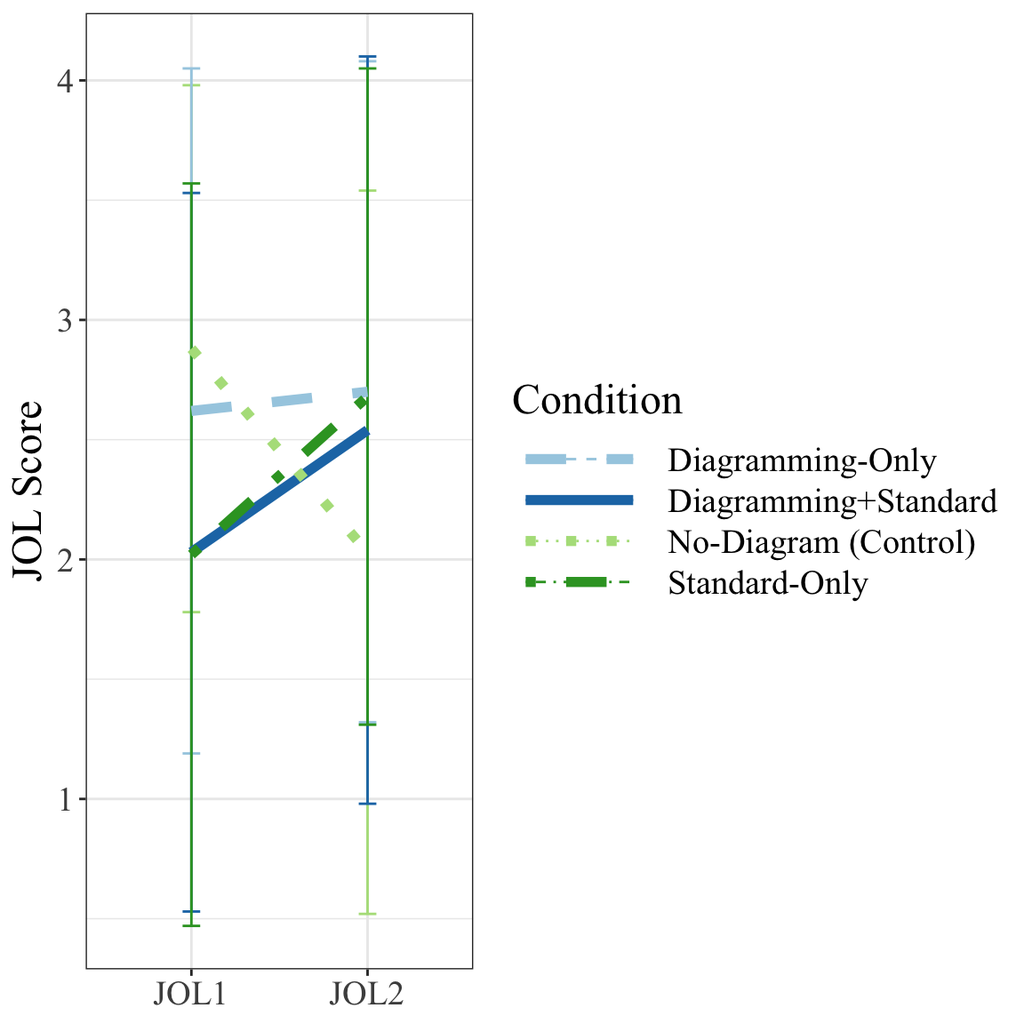

The model with the interaction explained significantly more variance compared to the model fitting only main effects *Chi<sup>2</sup>*(3) = 39.25 *p* = 0.000.

### *Pairwise Comparisons*

| contrast | estimate | SE | df | t.ratio | p.value | effect.size |
| --- | --- | --- | --- | --- | --- | --- |
| JoL1 No-Diagram-Control - JoL2 No-Diagram-Control | 0.85 | 0.19 | 876.00 | 4.48 | 0.000 | 0.59 |
| JoL1 No-Diagram-Control - JoL1 Diagramming-Only | 0.26 | 0.19 | 279.73 | 1.39 | 0.861 | 0.18 |
| JoL1 No-Diagram-Control - JoL2 Diagramming-Only | 0.18 | 0.19 | 279.73 | 0.95 | 0.981 | 0.12 |
| JoL1 No-Diagram-Control - JoL1 Diagramming+Standard | 0.85 | 0.19 | 279.73 | 4.48 | 0.000 | 0.59 |
| JoL1 No-Diagram-Control - JoL2 Diagramming+Standard | 0.34 | 0.19 | 279.73 | 1.80 | 0.619 | 0.24 |
| JoL1 No-Diagram-Control - JoL1 Standard-Only | 0.85 | 0.18 | 279.73 | 4.66 | 0.000 | 0.60 |
| JoL1 No-Diagram-Control - JoL2 Standard-Only | 0.20 | 0.18 | 279.73 | 1.07 | 0.963 | 0.14 |
| JoL2 No-Diagram-Control - JoL1 Diagramming-Only | -0.59 | 0.19 | 279.73 | -3.15 | 0.038 | -0.41 |
| JoL2 No-Diagram-Control - JoL2 Diagramming-Only | -0.67 | 0.19 | 279.73 | -3.59 | 0.009 | -0.47 |
| JoL2 No-Diagram-Control - JoL1 Diagramming+Standard | 0.00 | 0.19 | 279.73 | 0.00 | 1.000 | 0.00 |
| JoL2 No-Diagram-Control - JoL2 Diagramming+Standard | -0.51 | 0.19 | 279.73 | -2.68 | 0.133 | -0.35 |
| JoL2 No-Diagram-Control - JoL1 Standard-Only | 0.00 | 0.18 | 279.73 | 0.02 | 1.000 | 0.00 |
| JoL2 No-Diagram-Control - JoL2 Standard-Only | -0.66 | 0.18 | 279.73 | -3.58 | 0.010 | -0.46 |
| JoL1 Diagramming-Only - JoL2 Diagramming-Only | -0.08 | 0.19 | 876.00 | -0.45 | 1.000 | -0.06 |
| JoL1 Diagramming-Only - JoL1 Diagramming+Standard | 0.59 | 0.19 | 279.73 | 3.15 | 0.038 | 0.41 |
| JoL1 Diagramming-Only - JoL2 Diagramming+Standard | 0.08 | 0.19 | 279.73 | 0.44 | 1.000 | 0.06 |
| JoL1 Diagramming-Only - JoL1 Standard-Only | 0.59 | 0.18 | 279.73 | 3.29 | 0.025 | 0.41 |
| JoL1 Diagramming-Only - JoL2 Standard-Only | -0.07 | 0.18 | 279.73 | -0.36 | 1.000 | -0.05 |
| JoL2 Diagramming-Only - JoL1 Diagramming+Standard | 0.67 | 0.19 | 279.73 | 3.59 | 0.009 | 0.47 |
| JoL2 Diagramming-Only - JoL2 Diagramming+Standard | 0.16 | 0.19 | 279.73 | 0.88 | 0.988 | 0.12 |
| JoL2 Diagramming-Only - JoL1 Standard-Only | 0.68 | 0.18 | 279.73 | 3.75 | 0.005 | 0.47 |
| JoL2 Diagramming-Only - JoL2 Standard-Only | 0.02 | 0.18 | 279.73 | 0.10 | 1.000 | 0.01 |
| JoL1 Diagramming+Standard - JoL2 Diagramming+Standard | -0.51 | 0.19 | 876.00 | -2.68 | 0.130 | -0.35 |
| JoL1 Diagramming+Standard - JoL1 Standard-Only | 0.00 | 0.18 | 279.73 | 0.02 | 1.000 | 0.00 |
| JoL1 Diagramming+Standard - JoL2 Standard-Only | -0.66 | 0.18 | 279.73 | -3.58 | 0.010 | -0.46 |
| JoL2 Diagramming+Standard - JoL1 Standard-Only | 0.51 | 0.18 | 279.73 | 2.80 | 0.100 | 0.36 |
| JoL2 Diagramming+Standard - JoL2 Standard-Only | -0.15 | 0.18 | 279.73 | -0.80 | 0.993 | -0.10 |
| JoL1 Standard-Only - JoL2 Standard-Only | -0.66 | 0.18 | 876.00 | -3.74 | 0.005 | -0.46 |

# Study 2 - Methods

## Participants, Data Exclusion, Inter-Rate-Reliabilities & Reported Gaze Deviation

Descriptives of Age

| Mean | SD | Min | Max |
| --- | --- | --- | --- |
| 20.09 | 1.57 | 18 | 22 |

Gender Distribution

| Gender | n | % |
| --- | --- | --- |
| female | 17 | 77.27 |
| male | 5 | 22.73 |

Exclusion Criteria and Cases

|  | Cut-Off | n |
| --- | --- | --- |
| **Exclusion of** |  |  |
| Calibration Values | 1.34 | 5 |
| Tracking Ratios | < 75% | 2305 |
| **Gaze Data of Participants Analysed** |  |  |
|  |  | 2322 |

Agreement of raters for segmentation of verbal reports for coding

| (Dis-)Agreement | Perspective Coder 1 n | Perspective Coder 1 total segments | Perspective Coder 1 1 - n/total segments | Perspective Coder 1 n | Perspective Coder 1 total segments | Perspective Coder 1 1 - n/total segments |
| --- | --- | --- | --- | --- | --- | --- |
| Disagreement | 41 | 362 | **88.67** | 65 | 386 | **83.16** |
| Agreement | 321 | 362 | 11.33 | 321 | 386 | 16.84 |

Accuracy reported by the eye-tracker software was *M* = 0.68 (0.3).

# Study 2 - Results

## *Descriptives Fixations*

Descriptive Statistics of Total Fixation Durations per Diagram and Cue Type

No. of diagram boxes in eye-tracking data/ No. of diagram boxes in performance data

Average Total Fixation Duration of Single Box Per Cue Type (seconds)

% Total Fixations on Screen relative to screen duration

Diagram_Type

Cue_Type

n Gaze Data

n Performance Data

Mean

SD

Mean

SD

Outside Diagrams/AOIs

509.74

(1216.89)

64.49

(21.02)

OwnDiagram

Given_Box

50

98

63.85

(84.37)

5.29

(8.62)

OwnDiagram

Correct

9

195

166.53

(100.09)

0.75

(4.92)

OwnDiagram

Omission

1

49

142.72

(NA)

0.01

(0.09)

StandardDiagram

Given_Box

95

98

158.95

(212.54)

27.80

(17.69)

StandardDiagram

Correct

9

195

653.11

(1224.31)

1.21

(6.94)

StandardDiagram

Omission

1

49

7022.62

(NA)

0.45

(4.5)

OwnDiagram

Commission

0.00

StandardDiagram

Commission

0.00

OwnDiagram

6.05

(9.52)

StandardDiagram

29.46

(18.33)

Word Count of Diagram Responses

| Diagram_Type | Mean | SD | Min | Max |
| --- | --- | --- | --- | --- |
| OwnDiagram | 6.40 | 1.60 | 3 | 13 |
| StandardDiagram | 6.18 | 1.07 | 5 | 8 |

Participants wrote on average 0.22 words more in a box of their own diagram compared to words in a box of the standard.

## *Analysis Fixation Durations*

|  | Sum_AOI_Fixation_Duration_Sec |  |  |  |  |  |  |
| --- | --- | --- | --- | --- | --- | --- | --- |
| Predictors | Estimates | std. Error | std. Beta | standardized std. Error | CI | standardized CI | p |
| (Intercept) | 49.37 | 50.98 | -0.24 | 0.08 | -51.33 – 150.08 | -0.39 – -0.08 | 0.334 |
| Diagram Type [StandardDiagram] | 112.29 | 53.43 | 0.18 | 0.08 | 6.75 – 217.82 | 0.01 – 0.34 | **0.037** |
| Cue Type [Correct] | 155.44 | 125.47 | 0.24 | 0.20 | -92.39 – 403.27 | -0.15 – 0.63 | 0.217 |
| Cue Type [Omission] | -105.83 | 314.77 | -0.17 | 0.50 | -727.57 – 515.91 | -1.15 – 0.81 | 0.737 |
| Diagram Type [StandardDiagram] × Cue Type [Correct] | 374.30 | 152.24 | 0.59 | 0.24 | 73.59 – 675.00 | 0.12 – 1.06 | **0.015** |
| Diagram Type [StandardDiagram] × Cue Type [Omission] | 6767.61 | 431.00 | 10.65 | 0.68 | 5916.30 – 7618.92 | 9.31 – 12.00 | **<0.001** |
| Random Effects |  |  |  |  |  |  |  |
| σ<sup>2</sup> | 91453.52 |  |  |  |  |  |  |
| τ<sub>00</sub> <sub>Participant</sub> | 12466.30 |  |  |  |  |  |  |
| ICC | 0.12 |  |  |  |  |  |  |
| N <sub>Participant</sub> | 18 |  |  |  |  |  |  |
| Observations | 165 |  |  |  |  |  |  |
| Marginal R<sup>2</sup> / Conditional R<sup>2</sup> | 0.735 / 0.767 |  |  |  |  |  |  |

### *Pairwise comparisons*

| contrast | estimate | SE | df | t.ratio | p.value | effect.size |
| --- | --- | --- | --- | --- | --- | --- |
| OwnDiagram Given_Box - StandardDiagram Given_Box | -112.29 | 53.57 | 147.86 | -2.10 | 0.295 | -0.37 |
| OwnDiagram Given_Box - OwnDiagram Correct | -155.44 | 128.84 | 133.04 | -1.21 | 0.833 | -0.51 |
| OwnDiagram Given_Box - StandardDiagram Correct | -642.02 | 128.84 | 133.04 | -4.98 | 0.000 | -2.12 |
| OwnDiagram Given_Box - OwnDiagram Omission | 105.83 | 316.84 | 154.76 | 0.33 | 0.999 | 0.35 |
| OwnDiagram Given_Box - StandardDiagram Omission | -6774.07 | 316.84 | 154.76 | -21.38 | 0.000 | -22.40 |
| StandardDiagram Given_Box - OwnDiagram Correct | -43.15 | 124.11 | 132.29 | -0.35 | 0.999 | -0.14 |
| StandardDiagram Given_Box - StandardDiagram Correct | -529.74 | 124.11 | 132.29 | -4.27 | 0.001 | -1.75 |
| StandardDiagram Given_Box - OwnDiagram Omission | 218.11 | 315.40 | 154.70 | 0.69 | 0.983 | 0.72 |
| StandardDiagram Given_Box - StandardDiagram Omission | -6661.78 | 315.40 | 154.70 | -21.12 | 0.000 | -22.03 |
| OwnDiagram Correct - StandardDiagram Correct | -486.58 | 142.56 | 142.36 | -3.41 | 0.011 | -1.61 |
| OwnDiagram Correct - OwnDiagram Omission | 261.27 | 326.13 | 148.79 | 0.80 | 0.967 | 0.86 |
| OwnDiagram Correct - StandardDiagram Omission | -6618.63 | 326.13 | 148.79 | -20.29 | 0.000 | -21.89 |
| StandardDiagram Correct - OwnDiagram Omission | 747.85 | 326.13 | 148.79 | 2.29 | 0.203 | 2.47 |
| StandardDiagram Correct - StandardDiagram Omission | -6132.04 | 326.13 | 148.79 | -18.80 | 0.000 | -20.28 |
| OwnDiagram Omission - StandardDiagram Omission | -6879.89 | 427.68 | 142.36 | -16.09 | 0.000 | -22.75 |

## *Transition Table*

Average Number of Transitions per Trial and Transition Type

Transition Type

Code

n

% of Total

% Within Category

**Total Transitions**

Total number of all transitions

85

100.00

NA

**Between Diagrams**

Transitions between own diagram and standard

52

61.18

61.18

Correct box in own diagram - standard

1.a

18

21.18

34.62

Correct box in own diagram - matching box position in standard

a

12

14.12

66.67

Correct box in own diagram - matching content in standard

a

1

1.18

5.56

Correct box in own diagram - matching position and content in standard

a

2

2.35

11.11

Correct box in own diagram - not matching box content or position in standard

a

3

3.53

16.67

Mistake in own diagram - standard

1.ii

2

2.35

3.85

Commission - Standard

1.b

0

0.00

0.00

Commission in own diagram - matching box position in standard

b

0

0.00

NaN

Commission in own diagram - matching content* in standard

b

0

0.00

NaN

Commission in own diagram - matching position and content in standard

b

0

0.00

NaN

Commission in own diagram - not matching box content or position in standard

b

0

0.00

NaN

Omission - Standard

1.c

2

2.35

100.00

Omission in own diagram - matching box position in standard

c

2

2.35

100.00

Omission in own diagram - not matching box position in standard

c

0

0.00

0.00

Given box in own diagram - standard

1.d

32

37.65

61.54

**Within Diagrams**

Transitions within diagrams

33

38.82

38.82

Within own diagram

2.a

7

8.24

21.21

Within standard

2.b

26

30.59

78.79

Participants made between 1 and 31 fixation transitions throughout the study, ( *M* = 5.67, *SD* = 8.89).

## *Cued Retrospective Verbal Reports*

Average Frequencies and Proportion of Code Categories per Participant and Entire Sample

| Code | During Diagram Study & JOL Screen Total n | During Diagram Study & JOL Screen Total % | During Diagram Study & JOL Screen Average frequency per participant Mean | During Diagram Study & JOL Screen Average frequency per participant SD | During Diagram Study & JOL Screen Mentioned by n | During Diagram Study & JOL Screen Mentioned by % | During JOL Screen Only Total n | During JOL Screen Only Total % | During JOL Screen Only Average frequency per participant Mean | During JOL Screen Only Average frequency per participant SD | During JOL Screen Only Mentioned by n | During JOL Screen Only Mentioned by % |
| --- | --- | --- | --- | --- | --- | --- | --- | --- | --- | --- | --- | --- |
| 1 | 50 | 3.69 | 2.78 | 1.63 | 18 | 85.71 | 17 | 4.03 | 1.55 | 0.69 | 11 | 52.38 |
| 2 | 2 | 0.15 | NA | NA | 2 | 9.52 | 1 | 0.24 | 1.00 | NA | 1 | 4.76 |
| 3 | 44 | 3.25 | 2.44 | 1.69 | 18 | 85.71 | 12 | 2.84 | 1.50 | 0.76 | 8 | 38.10 |
| 4 | 8 | 0.59 | 1.33 | 0.52 | 6 | 28.57 | 5 | 1.18 | 1.00 | 0.00 | 5 | 23.81 |
| 5 | 34 | 2.51 | 1.89 | 0.83 | 18 | 85.71 | 9 | 2.13 | 1.00 | 0.00 | 9 | 42.86 |
| 6 | 5 | 0.37 | 1.67 | 0.58 | 3 | 14.29 | 3 | 0.71 | 1.50 | 0.71 | 2 | 9.52 |
| 7a | 45 | 3.32 | 2.50 | 1.04 | 18 | 85.71 | 13 | 3.08 | 1.44 | 0.73 | 9 | 42.86 |
| 7b | 36 | 2.66 | 2.40 | 1.99 | 15 | 71.43 | 8 | 1.90 | 1.14 | 0.38 | 7 | 33.33 |
| 8a | 65 | 4.80 | 3.42 | 1.68 | 19 | 90.48 | 18 | 4.27 | 1.50 | 0.52 | 12 | 57.14 |
| 8b | 26 | 1.92 | 1.86 | 0.95 | 14 | 66.67 | 7 | 1.66 | 1.17 | 0.41 | 6 | 28.57 |
| 8c | 109 | 8.05 | 5.19 | 2.96 | 21 | 100.00 | 39 | 9.24 | 2.17 | 1.04 | 18 | 85.71 |
| 8d | 90 | 6.65 | 4.29 | 2.61 | 21 | 100.00 | 28 | 6.64 | 2.15 | 1.14 | 13 | 61.90 |
| 9 | 105 | 7.75 | 5.25 | 2.43 | 20 | 95.24 | 33 | 7.82 | 1.94 | 0.90 | 17 | 80.95 |
| 10a | 118 | 8.71 | 5.62 | 2.85 | 21 | 100.00 | 41 | 9.72 | 2.28 | 1.18 | 18 | 85.71 |
| 10b | 54 | 3.99 | 3.00 | 1.85 | 18 | 85.71 | 21 | 4.98 | 1.62 | 1.12 | 13 | 61.90 |
| 11 | 19 | 1.40 | 1.58 | 1.00 | 12 | 57.14 | 5 | 1.18 | 1.25 | 0.50 | 4 | 19.05 |
| 12 | 32 | 2.36 | 1.68 | 1.06 | 19 | 90.48 | 13 | 3.08 | 1.30 | 0.67 | 10 | 47.62 |
| 13a | 249 | 18.39 | 11.86 | 5.24 | 21 | 100.00 | 69 | 16.35 | 3.45 | 1.76 | 20 | 95.24 |
| 13b | 76 | 5.61 | 3.80 | 1.77 | 20 | 95.24 | 16 | 3.79 | 1.23 | 0.44 | 13 | 61.90 |
| 14 | 4 | 0.30 | 1.00 | 0.00 | 4 | 19.05 | 2 | 0.47 | 1.00 | 0.00 | 2 | 9.52 |
| 15 | 183 | 13.52 | 8.71 | 3.95 | 21 | 100.00 | 62 | 14.69 | 3.10 | 1.97 | 20 | 95.24 |

The total number of coded segments was 1354, with 422 voiced during the JOL screen.

## *Cue Values, Cue Diagnosticity and Cue Utilization*

### *Study 1 and 2*

Descriptive Statistics Cue Values, Cue Diagnosticity and Cue Utilization

| Experiment | Condition | Correct Mean | Correct SD | Correct Min | Correct Max | Correct NAs | Commission Mean | Commission SD | Commission Min | Commission Max | Commission NAs | Omission Mean | Omission SD | Omission Min | Omission Max | Omission NAs |
| --- | --- | --- | --- | --- | --- | --- | --- | --- | --- | --- | --- | --- | --- | --- | --- | --- |
| **Cue Value** |  |  |  |  |  |  |  |  |  |  |  |  |  |  |  |  |
| 1 | Diagramming+Standard | 2.66 | 0.96 | 0.00 | 6.00 | 0 | 0.74 | 0.79 | 0.00 | 3.00 | 0 | 0.59 | 0.75 | 0.00 | 3.00 | 0 |
| 1 | Diagramming-Only | 2.82 | 1.00 | 0.00 | 4.00 | 0 | 0.60 | 0.75 | 0.00 | 3.00 | 0 | 0.61 | 0.77 | 0.00 | 3.00 | 0 |
| 2 | Diagramming+Standard | 2.84 | 1.00 | 0.00 | 4.00 | 0 | 0.74 | 0.82 | 0.00 | 3.00 | 0 | 0.54 | 0.71 | 0.00 | 3.00 | 0 |
| **Cue Diagnosticity** |  |  |  |  |  |  |  |  |  |  |  |  |  |  |  |  |
| 1 | Diagramming+Standard | -0.13 | 0.46 | -0.80 | 0.78 | 2 | -0.13 | 0.46 | -0.81 | 0.61 | 2 | 0.07 | 0.47 | -0.91 | 0.81 | 2 |
| 1 | Diagramming-Only | -0.03 | 0.43 | -0.56 | 0.87 | 0 | 0.03 | 0.38 | -0.47 | 0.86 | 2 | 0.16 | 0.26 | -0.44 | 0.49 | 1 |
| 2 | Diagramming+Standard | -0.01 | 0.49 | -0.63 | 0.84 | 1 | -0.09 | 0.47 | -0.82 | 0.91 | 1 | -0.11 | 0.49 | -0.89 | 0.63 | 2 |
| **Cue Utilization** |  |  |  |  |  |  |  |  |  |  |  |  |  |  |  |  |
| 1 | Diagramming+Standard | -0.04 | 0.43 | -0.83 | 0.78 | 0 | -0.11 | 0.41 | -0.73 | 0.66 | 0 | 0.04 | 0.49 | -0.76 | 0.76 | 0 |
| 1 | Diagramming-Only | 0.07 | 0.44 | -0.53 | 0.88 | 0 | 0.02 | 0.48 | -0.88 | 0.75 | 2 | 0.03 | 0.47 | -1.00 | 0.97 | 1 |
| 2 | Diagramming+Standard | -0.08 | 0.40 | -0.66 | 0.77 | 0 | -0.07 | 0.39 | -0.79 | 0.60 | 0 | -0.05 | 0.46 | -0.98 | 0.78 | 1 |

### *Differences between conditions of Study 1*

|  | Cue_Value_Correct |  |  | Cue_Value_Commission |  |  | Cue_Value_Omission |  |  |
| --- | --- | --- | --- | --- | --- | --- | --- | --- | --- |
| Predictors | Estimates | CI | p | Estimates | CI | p | Estimates | CI | p |
| (Intercept) | 2.82 | 2.64 – 2.99 | **<0.001** | 0.60 | 0.46 – 0.74 | **<0.001** | 0.61 | 0.47 – 0.75 | **<0.001** |
| Condition [Diagramming+Standard] | -0.16 | -0.41 – 0.09 | 0.215 | 0.14 | -0.06 – 0.33 | 0.175 | -0.02 | -0.22 – 0.18 | 0.836 |
| Observations | 234 |  |  | 234 |  |  | 234 |  |  |
| R<sup>2</sup> / R<sup>2</sup> adjusted | 0.007 / 0.002 |  |  | 0.008 / 0.004 |  |  | 0.000 / -0.004 |  |  |

|  | Cue_Diag_Correct |  |  | Cue_Diag_Commission |  |  | Cue_Diag_Omission |  |  |
| --- | --- | --- | --- | --- | --- | --- | --- | --- | --- |
| Predictors | Estimates | CI | p | Estimates | CI | p | Estimates | CI | p |
| (Intercept) | -0.03 | -0.24 – 0.17 | 0.746 | 0.03 | -0.17 – 0.24 | 0.739 | 0.16 | -0.01 – 0.34 | 0.068 |
| Condition [Diagramming+Standard] | -0.10 | -0.40 – 0.20 | 0.498 | -0.17 | -0.46 – 0.13 | 0.255 | -0.09 | -0.34 – 0.16 | 0.479 |
| Observations | 37 |  |  | 35 |  |  | 36 |  |  |
| R<sup>2</sup> / R<sup>2</sup> adjusted | 0.013 / -0.015 |  |  | 0.039 / 0.010 |  |  | 0.015 / -0.014 |  |  |

|  | Cue_Util_Correct |  |  | Cue_Util_Commission |  |  | Cue_Util_Omission |  |  |
| --- | --- | --- | --- | --- | --- | --- | --- | --- | --- |
| Predictors | Estimates | CI | p | Estimates | CI | p | Estimates | CI | p |
| (Intercept) | 0.07 | -0.13 – 0.27 | 0.468 | 0.02 | -0.19 – 0.23 | 0.837 | 0.03 | -0.19 – 0.26 | 0.754 |
| Condition [Diagramming+Standard] | -0.12 | -0.40 – 0.17 | 0.413 | -0.13 | -0.43 – 0.16 | 0.372 | 0.00 | -0.32 – 0.32 | 0.997 |
| Observations | 39 |  |  | 37 |  |  | 38 |  |  |
| R<sup>2</sup> / R<sup>2</sup> adjusted | 0.018 / -0.008 |  |  | 0.023 / -0.005 |  |  | 0.000 / -0.028 |  |  |

### *Differences between Study 1 and 2*

|  | Cue_Value_Correct |  |  | Cue_Value_Commission |  |  | Cue_Value_Omission |  |  |
| --- | --- | --- | --- | --- | --- | --- | --- | --- | --- |
| Predictors | Estimates | CI | p | Estimates | CI | p | Estimates | CI | p |
| (Intercept) | 2.63 | 2.33 – 2.94 | **<0.001** | 0.60 | 0.35 – 0.84 | **<0.001** | 0.65 | 0.42 – 0.88 | **<0.001** |
| Experiment | 0.11 | -0.11 – 0.32 | 0.330 | 0.07 | -0.10 – 0.24 | 0.421 | -0.06 | -0.22 – 0.10 | 0.494 |
| Observations | 363 |  |  | 363 |  |  | 363 |  |  |
| R<sup>2</sup> / R<sup>2</sup> adjusted | 0.003 / -0.000 |  |  | 0.002 / -0.001 |  |  | 0.001 / -0.001 |  |  |

|  | Cue_Diag_Correct |  |  | Cue_Diag_Commission |  |  | Cue_Diag_Omission |  |  |
| --- | --- | --- | --- | --- | --- | --- | --- | --- | --- |
| Predictors | Estimates | CI | p | Estimates | CI | p | Estimates | CI | p |
| (Intercept) | -0.14 | -0.51 – 0.22 | 0.435 | -0.00 | -0.36 – 0.36 | 0.989 | 0.35 | 0.02 – 0.69 | **0.040** |
| Experiment | 0.06 | -0.19 – 0.32 | 0.612 | -0.04 | -0.29 – 0.20 | 0.718 | -0.23 | -0.46 – 0.00 | 0.051 |
| Observations | 58 |  |  | 56 |  |  | 56 |  |  |
| R<sup>2</sup> / R<sup>2</sup> adjusted | 0.005 / -0.013 |  |  | 0.002 / -0.016 |  |  | 0.069 / 0.051 |  |  |

|  | Cue_Util_Correct |  |  | Cue_Util_Commission |  |  | Cue_Util_Omission |  |  |
| --- | --- | --- | --- | --- | --- | --- | --- | --- | --- |
| Predictors | Estimates | CI | p | Estimates | CI | p | Estimates | CI | p |
| (Intercept) | 0.11 | -0.22 – 0.43 | 0.505 | -0.02 | -0.36 – 0.31 | 0.881 | 0.12 | -0.25 – 0.49 | 0.511 |
| Experiment | -0.09 | -0.32 – 0.13 | 0.407 | -0.02 | -0.25 – 0.21 | 0.855 | -0.09 | -0.34 – 0.17 | 0.501 |
| Observations | 61 |  |  | 59 |  |  | 59 |  |  |
| R<sup>2</sup> / R<sup>2</sup> adjusted | 0.012 / -0.005 |  |  | 0.001 / -0.017 |  |  | 0.008 / -0.009 |  |  |

For completeness: the adjusted p-values for multiple testing for the cue values were 0.99, 0.99, 0.99 and for the cue diagnosticities and cue utilizations 1, 1, 0.307, 1, 1, 1.

…